# Final Project

Collins Kwasi Apenteng, Mbye Sallah

2024-05-03

In this project, we conduct a thorough analysis involving data preprocessing, model training, and model validation on the effectiveness of machine learning (ML) models in predicting coronary artery disease (CAD). Our evaluation focuses on several key performance metrics including accuracy rates, sensitivity, ROC, and Area Under Curve (AUC). We show that among these classifiers, the SVM performs better in terms of predictive accuracy, sensitivity, and AUC.

# Data Exploration

#### Loading Libraries

```r
library(e1071)
library(ROCR)
library(class)
library(tree)
library(randomForest)
library(tidyverse)
```

#### Importing the Data

```r
sani = read.csv("Sani_Data.csv")
sani_backup =sani
names(sani)
```

```
 [1] "Age"                   "Weight"                "Length"
 [4] "Sex"                   "BMI"                   "DM"
 [7] "HTN"                   "Current.Smoker"        "EX.Smoker"
[10] "FH"                    "Obesity"               "CRF"
[13] "CVA"                   "Airway.disease"        "Thyroid.Disease"
[16] "CHF"                   "DLP"                   "BP"
[19] "PR"                    "Edema"                 "Weak.Peripheral.Pulse"
[22] "Lung.rales"            "Systolic.Murmur"       "Diastolic.Murmur"
[25] "Typical.Chest.Pain"    "Dyspnea"               "Function.Class"
[28] "Atypical"              "Nonanginal"            "Exertional.CP"
[31] "LowTH.Ang"             "Q.Wave"                "St.Elevation"
[34] "St.Depression"         "Tinversion"            "LVH"
[37] "Poor.R.Progression"    "BBB"                   "FBS"
[40] "CR"                    "TG"                    "LDL"
[43] "HDL"                   "BUN"                   "ESR"
[46] "HB"                    "K"                     "Na"
[49] "WBC"                   "Lymph"                 "Neut"
[52] "PLT"                   "EF.TTE"                "Region.RWMA"
[55] "VHD"                   "Cath"
```

The dataset contains 56 features (variabls) on 303 individuals. Not all the features are relevant. As a practice in predictive modelling, we first explored the dataset and select the relavant features.

```r
any(is.na(sani))
```

```
[1] FALSE
```

#### Feature selection Process

This is how we select our relevant variables. We use random forest for feature selection. Previous studies used SVM weight, correlation matrix, and principal component analysis. However, Kursa and Rudnicki (2011) showed that using a Random Forest algorithm to identify and rank the most relevant features for predicting the outcome yields reasonable accuracy.

```r
# Convert all character and integer columns that are categorical to factors
sani = sani %>%
  mutate_if(is.character, as.factor) %>%  # Converts all character columns to factors
  mutate_if(is.integer, function(x) {     # Converts integer columns if they are categorical
    if (n_distinct(x) < 10) {             # Assuming categorical if fewer than 10 unique values
      as.factor(x)
    } else {
      x                                   # Leaves the column as is if it's likely numeric
    }
  })

str(sani)
```

```
'data.frame':   303 obs. of  56 variables:
 $ Age                  : int  53 67 54 66 50 50 55 72 58 60 ...
 $ Weight               : int  90 70 54 67 87 75 80 80 84 71 ...
 $ Length               : int  175 157 164 158 153 175 165 175 163 170 ...
 $ Sex                  : Factor w/ 2 levels "Fmale","Male": 2 1 2 1 1 2 2 2 1 2 ...
 $ BMI                  : num  29.4 28.4 20.1 26.8 37.2 ...
 $ DM                   : Factor w/ 2 levels "0","1": 1 1 1 1 1 1 1 2 1 2 ...
 $ HTN                  : Factor w/ 2 levels "0","1": 2 2 1 2 2 1 1 1 1 1 ...
 $ Current.Smoker       : Factor w/ 2 levels "0","1": 2 1 2 1 1 2 1 2 1 1 ...
 $ EX.Smoker            : Factor w/ 2 levels "0","1": 1 1 1 1 1 1 2 1 1 1 ...
 $ FH                   : Factor w/ 2 levels "0","1": 1 1 1 1 1 1 1 1 1 1 ...
 $ Obesity              : Factor w/ 2 levels "N","Y": 2 2 1 2 2 1 2 2 2 1 ...
 $ CRF                  : Factor w/ 2 levels "N","Y": 1 1 1 1 1 1 1 1 1 1 ...
 $ CVA                  : Factor w/ 2 levels "N","Y": 1 1 1 1 1 1 1 1 1 1 ...
 $ Airway.disease       : Factor w/ 2 levels "N","Y": 1 1 1 1 1 1 1 1 1 1 ...
```

[output cut: 42 more lines]

```r
# Train the model with importance=TRUE to ensure importance scores are calculated
rf_model = randomForest(Cath ~ ., data = sani, ntree = 500, importance = TRUE)

# Extracting importance scores
importance_scores = importance(rf_model)
feature_importance = importance_scores[, "MeanDecreaseAccuracy"]

# Sort features by importance
sorted_features = sort(feature_importance, decreasing = TRUE)
top_15_features = names(sorted_features)[1:15] # Select top 15 features
print(top_15_features)
```

```
 [1] "Typical.Chest.Pain" "Age"                "Atypical"
 [4] "Region.RWMA"        "Nonanginal"         "EF.TTE"
 [7] "HTN"                "ESR"                "Tinversion"
[10] "TG"                 "VHD"                "BP"
[13] "FBS"                "Diastolic.Murmur"   "PR"
```

We found that other studies have used similar variables as relevant features of the data. We were surprised sex was not listed as relevant but we found that some previous studies did not use sex. Perhaps it has no significant influence on CAD.

# Summary Statistics and Data Visualization

#### Summary Statistics

```r
# Age
summary(sani$Age)
```

```
   Min. 1st Qu.  Median    Mean 3rd Qu.    Max.
   30.0    51.0    58.0    58.9    66.0    86.0
```

```r
# Blood pressure
summary(sani$BP)
```

```
   Min. 1st Qu.  Median    Mean 3rd Qu.    Max.
   90.0   120.0   130.0   129.6   140.0   190.0
```

```r
# Ejection fraction percentage
summary(sani$EF.TTE)
```

```
   Min. 1st Qu.  Median    Mean 3rd Qu.    Max.
  15.00   45.00   50.00   47.23   55.00   60.00
```

```r
# Triglycerides
summary(sani$TG)
```

```
   Min. 1st Qu.  Median    Mean 3rd Qu.    Max.
   37.0    90.0   122.0   150.3   177.0  1050.0
```

```r
# erythrocyte sedimentation rate
summary(sani$ESR)
```

```
   Min. 1st Qu.  Median    Mean 3rd Qu.    Max.
   1.00    9.00   15.00   19.46   26.00   90.00
```

```r
# Fasting Blood Sugar
summary(sani$FBS)
```

```
   Min. 1st Qu.  Median    Mean 3rd Qu.    Max.
   62.0    88.5    98.0   119.2   130.0   400.0
```

##### Filter the data to get only those that have CAD

```r
sani_cad = filter(sani, Cath == "Cad")
```

##### Calculate the standad deviation for only those that got CAD

```r
# Age
sd(sani_cad$Age)
```

```
[1] 9.878918
```

```r
# Blood pressure
sd(sani_cad$BP)
```

```
[1] 18.4764
```

```r
# Ejection fraction percentage
sd(sani_cad$EF.TTE)
```

```
[1] 8.94379
```

```r
# Triglycerides
sd(sani_cad$TG)
```

```
[1] 104.5474
```

```r
# erythrocyte sedimentation rate
sd(sani_cad$ESR)
```

```
[1] 16.43054
```

```r
# Fasting Blood Sugar
sd(sani_cad$FBS)
```

```
[1] 56.25502
```

##### Calculate the summary stats for only those that got CAD

```r
# Age
summary(sani_cad$Age)
```

```
   Min. 1st Qu.  Median    Mean 3rd Qu.    Max.
  36.00   54.00   61.50   61.25   69.00   86.00
```

```r
# Blood pressure
summary(sani_cad$BP)
```

```
   Min. 1st Qu.  Median    Mean 3rd Qu.    Max.
   90.0   120.0   130.0   132.4   140.0   190.0
```

```r
# Ejection fraction percentage
summary(sani_cad$EF.TTE)
```

```
   Min. 1st Qu.  Median    Mean 3rd Qu.    Max.
  15.00   40.00   45.50   45.91   51.25   60.00
```

```r
# Triglycerides
summary(sani_cad$TG)
```

```
   Min. 1st Qu.  Median    Mean 3rd Qu.    Max.
   50.0    95.0   130.0   159.1   190.0  1050.0
```

```r
# erythrocyte sedimentation rate
summary(sani_cad$ESR)
```

```
   Min. 1st Qu.  Median    Mean 3rd Qu.    Max.
   1.00   10.00   16.00   21.26   29.25   90.00
```

```r
# Fasting Blood Sugar
summary(sani_cad$FBS)
```

```
   Min. 1st Qu.  Median    Mean 3rd Qu.    Max.
   62.0    90.0   103.0   126.0   144.2   400.0
```

```r
sani_normal = filter(sani, Cath == "Normal")
```

##### Calculate the summary stats for normal people

```r
# Age
summary(sani_normal$Age)
```

```
   Min. 1st Qu.  Median    Mean 3rd Qu.    Max.
  30.00   47.50   52.00   53.06   57.50   79.00
```

```r
# Blood pressure
summary(sani_normal$BP)
```

```
   Min. 1st Qu.  Median    Mean 3rd Qu.    Max.
   90.0   110.0   120.0   122.5   130.0   180.0
```

```r
# Ejection fraction percentage
summary(sani_normal$EF.TTE)
```

```
   Min. 1st Qu.  Median    Mean 3rd Qu.    Max.
  15.00   50.00   55.00   50.52   55.00   60.00
```

```r
# Triglycerides
summary(sani_normal$TG)
```

```
   Min. 1st Qu.  Median    Mean 3rd Qu.    Max.
   37.0    85.0   110.0   128.7   138.0   450.0
```

```r
# erythrocyte sedimentation rate
summary(sani_normal$ESR)
```

```
   Min. 1st Qu.  Median    Mean 3rd Qu.    Max.
   1.00    5.50   12.00   14.99   19.00   76.00
```

```r
# Fasting Blood Sugar
summary(sani_normal$FBS)
```

```
   Min. 1st Qu.  Median    Mean 3rd Qu.    Max.
   65.0    84.0    92.0   102.3   104.0   300.0
```

##### Summary table of some categorical variables

```r
#typical chest pain and CAD
table(sani$Typical.Chest.Pain, sani$Cath)
```

```
    Cad Normal
  0  62     77
  1 154     10
```

People with typical chest pain are more likely to have CAD

```r
# Atypcal and CAD
table(sani$Atypical, sani$Cath)
```

```
    Cad Normal
  N 176     34
  Y  40     53
```

Those who are not atypical are more likely to have CAD

```r
# Hyper tension and CAD
table(sani$HTN, sani$Cath)
```

```
    Cad Normal
  0  69     55
  1 147     32
```

You are more likely to have CAD if you have Hyper tension

```r
# Valvular Heart Disease and CAD
table(sani$VHD, sani$Cath)
```

```
           Cad Normal
  mild     115     34
  Moderate  22      5
  N         76     40
  Severe     3      8
```

```r
# Diabetes and CAD
table(sani$DM, sani$Cath) # Those who have diabetes are more likely to have CAD
```

```
    Cad Normal
  0 136     77
  1  80     10
```

#### Age Distribution

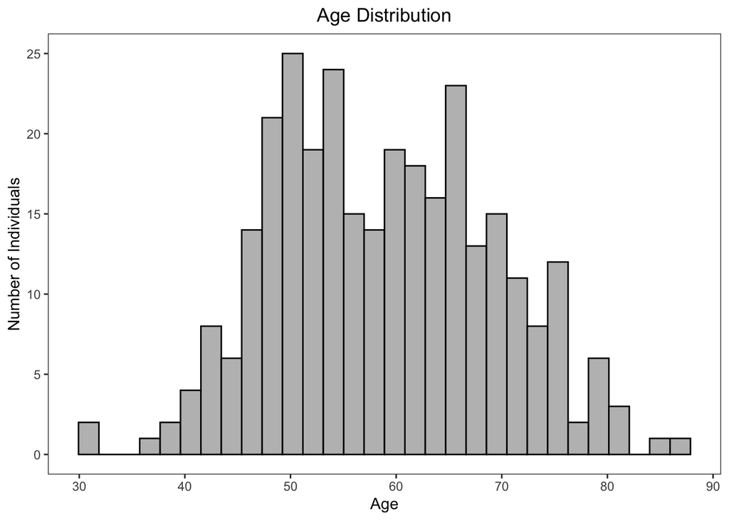

```r
ggplot(sani) +
  geom_histogram(aes(Age), fill = "gray", col = "black") +
  labs(x = "Age", y = "Number of Individuals", title = "Age Distribution") + theme_bw() +   theme(panel.grid.major = element_blank(),
  panel.grid.minor = element_blank()) +
  theme(plot.title = element_text(hjust = 0.5))
```

### Make the variables categorical

```r
sani$Typical.Chest.Pain = as.factor(sani$Typical.Chest.Pain)
```

#### Relationship between blood presure and age

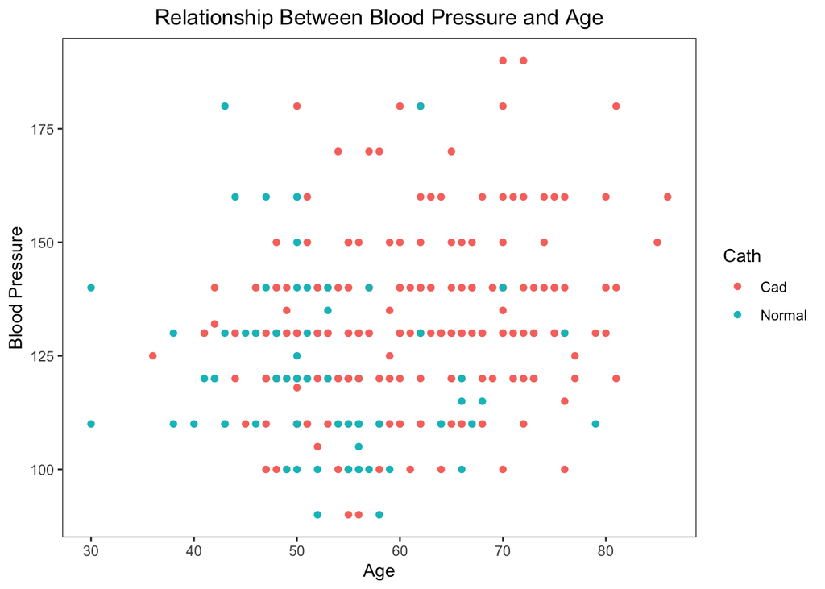

```r
ggplot(sani) +
  geom_point(aes(x = Age, y = BP, color = Cath)) +
  labs(title = "Relationship Between Blood Pressure and Age", y = "Blood Pressure") + theme_bw() +   theme(panel.grid.major = element_blank(),
  panel.grid.minor = element_blank()) +
  theme(plot.title = element_text(hjust = 0.5))
```

### Relationship between erythrocyte sedimentation rate and Age

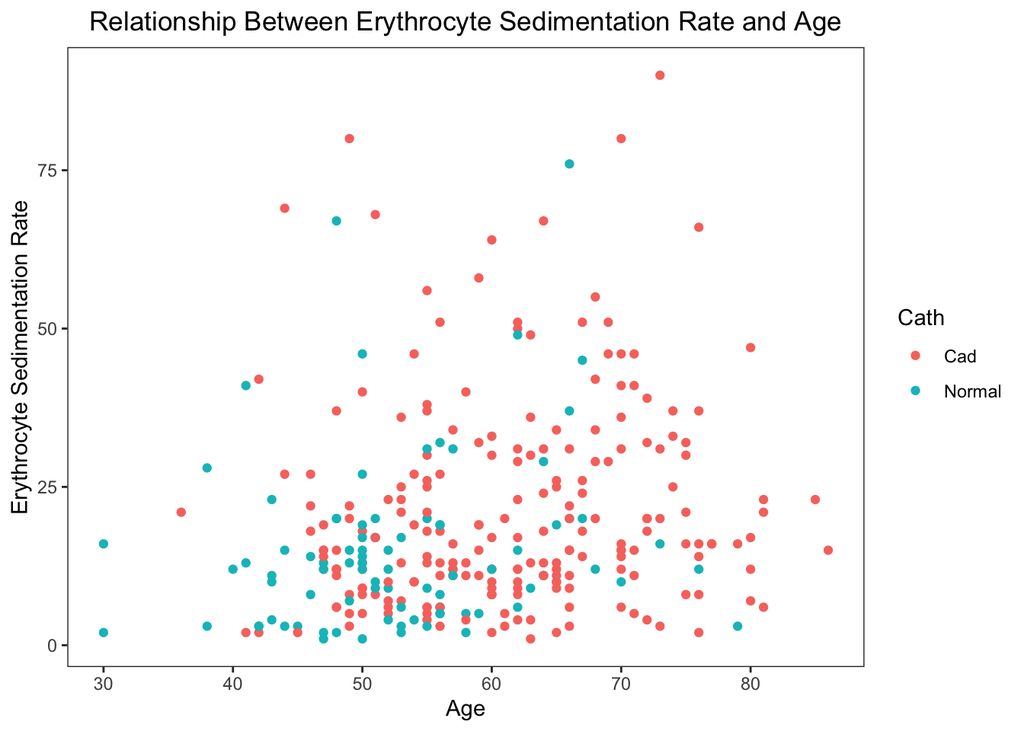

```r
ggplot(sani) +
  geom_point(aes(x = Age, y = ESR, color = Cath)) +
  labs(title = "Relationship Between Erythrocyte Sedimentation Rate and Age", y = "Erythrocyte Sedimentation Rate") + theme_bw() +   theme(panel.grid.major = element_blank(),
  panel.grid.minor = element_blank()) +
  theme(plot.title = element_text(hjust = 0.5))
```

#### Relationship between ejection fraction and age

[figure not shown]

```r
ggplot(sani) +
  geom_point(aes(x = Age, y = EF.TTE, color = Cath)) +
  labs(title = "Relationship Between Ejection Fraction and Blood Pressure", x = "Blood Pressure", y = "Ejection Fraction (%)", ) + theme_bw() +   theme(panel.grid.major = element_blank(),
  panel.grid.minor = element_blank()) +
  theme(plot.title = element_text(hjust = 0.5))
```

#### Relationship Between Fasting Blood Sugar and Age

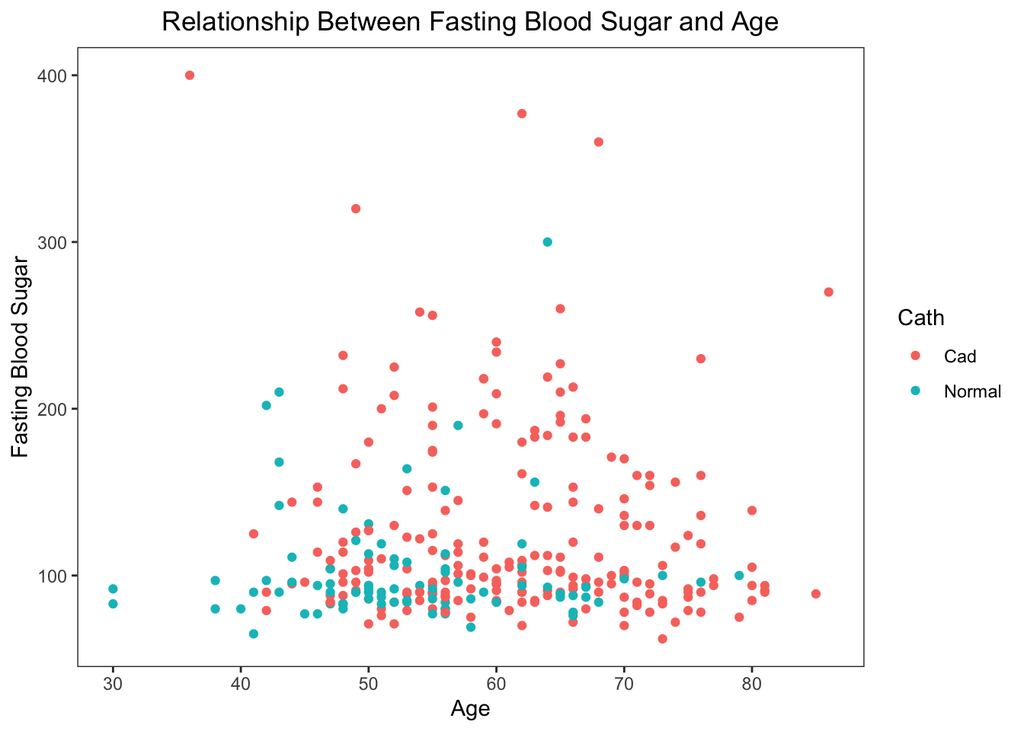

```r
ggplot(sani) +
  geom_point(aes(x = Age, y = FBS, color = Cath)) +
  labs(title = "Relationship Between Fasting Blood Sugar and Age", y = "Fasting Blood Sugar") + theme_bw() +   theme(panel.grid.major = element_blank(),
  panel.grid.minor = element_blank()) +
  theme(plot.title = element_text(hjust = 0.5))
```

#### Relationship Between Fasting Blood Sugar and Blood Pressure

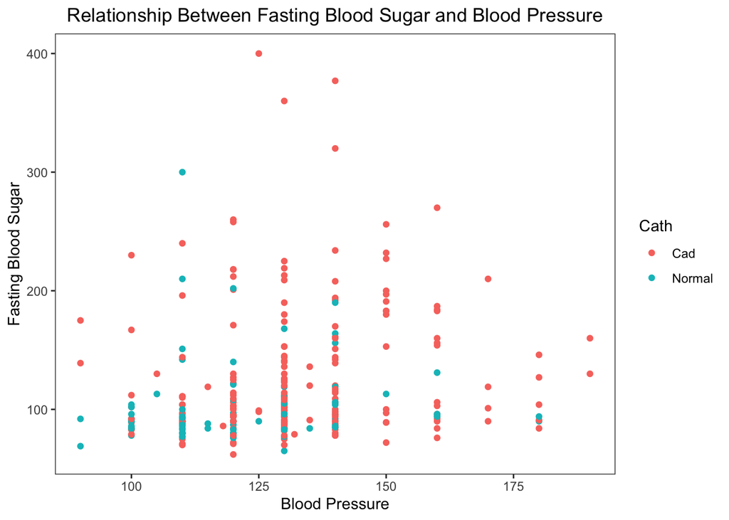

```r
ggplot(sani) +
  geom_point(aes(x = BP, y = FBS, color = Cath)) +
  labs(title = "Relationship Between Fasting Blood Sugar and Blood Pressure", x = "Blood Pressure", y = "Fasting Blood Sugar") + theme_bw() +   theme(panel.grid.major = element_blank(),
  panel.grid.minor = element_blank()) +
  theme(plot.title = element_text(hjust = 0.5))
```

#### Relationship Between ejection fraction and erythrocyte sedimentation rate

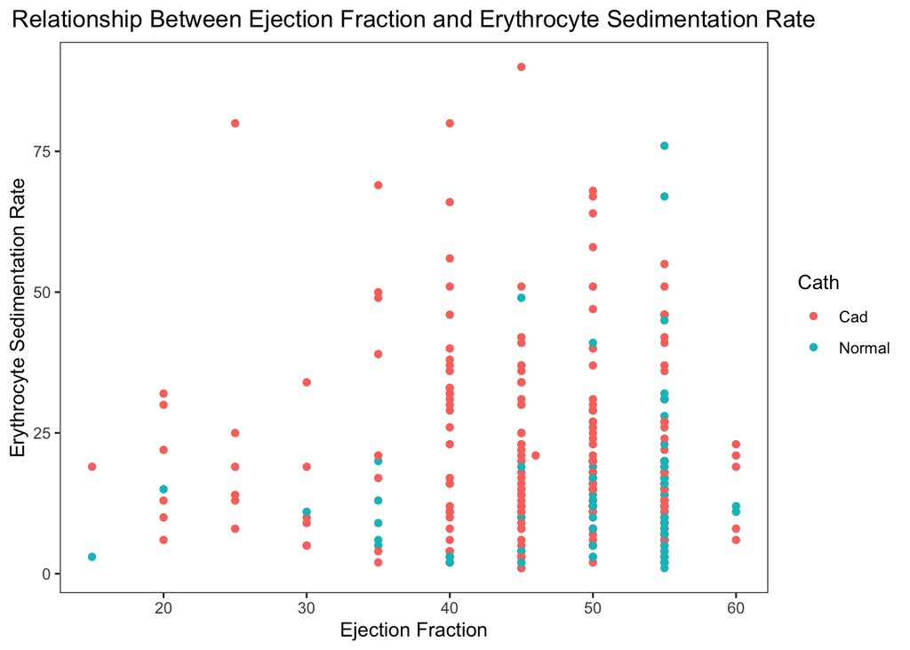

```r
ggplot(sani) +
  geom_point(aes(x = EF.TTE, y = ESR, color = Cath)) +
  labs(title = "Relationship Between Ejection Fraction and Erythrocyte Sedimentation Rate", x = "Ejection Fraction", y = "Erythrocyte Sedimentation Rate") + theme_bw() +   theme(panel.grid.major = element_blank(),
  panel.grid.minor = element_blank()) +
  theme(plot.title = element_text(hjust = 0.5))
```

```r
sani=subset(sani_backup, select = c(Cath,Typical.Chest.Pain,Atypical,Age,Region.RWMA,EF.TTE,Nonanginal,Tinversion,HTN,BP,ESR,CR,DM,VHD,TG,FBS))
str(sani)
```

```
'data.frame':   303 obs. of  16 variables:
 $ Cath              : chr  "Cad" "Cad" "Cad" "Normal" ...
 $ Typical.Chest.Pain: int  0 1 1 0 0 1 1 1 0 1 ...
 $ Atypical          : chr  "N" "N" "N" "N" ...
 $ Age               : int  53 67 54 66 50 50 55 72 58 60 ...
 $ Region.RWMA       : int  0 4 2 0 0 0 4 4 0 2 ...
 $ EF.TTE            : int  50 40 40 55 50 50 40 45 50 40 ...
 $ Nonanginal        : chr  "N" "N" "N" "Y" ...
 $ Tinversion        : int  1 1 0 0 0 0 1 1 0 0 ...
 $ HTN               : int  1 1 0 1 1 0 0 0 0 0 ...
 $ BP                : int  110 140 100 100 110 118 110 130 90 130 ...
 $ ESR               : int  7 26 10 76 27 18 38 4 5 8 ...
 $ CR                : num  0.7 1 1 1.2 1 1 0.8 0.9 0.6 1.3 ...
 $ DM                : int  0 0 0 0 0 0 0 1 0 1 ...
 $ VHD               : chr  "N" "N" "mild" "Severe" ...
 $ TG                : int  250 309 103 63 170 139 83 80 79 80 ...
 $ FBS               : int  90 80 85 78 104 86 80 130 69 209 ...
```

See the distinct levels under each categorical variable

```r
unique(sani$Cath)
```

```
[1] "Cad"    "Normal"
```

```r
unique(sani$Atypical)
```

```
[1] "N" "Y"
```

```r
unique(sani$Nonanginal)
```

```
[1] "N" "Y"
```

```r
unique(sani$VHD)
```

```
[1] "N"        "mild"     "Severe"   "Moderate"
```

```r
# Recoding features in the data
sani$Cath = ifelse(sani$Cath == "Cad", 1, 0)
sani$Atypical = ifelse(sani$Atypical == "Y", 1, 0)
sani$Nonanginal = ifelse(sani$Nonanginal == "Y", 1, 0)
sani$VHD = as.numeric(factor(sani$VHD, levels = c("N", "mild", "Moderate", "Severe"), labels = c(0, 1, 2, 3)))

sani$Cath = as.factor(sani$Cath)
sani$Atypical = as.factor(sani$Atypical)
sani$Nonanginal = as.factor(sani$Nonanginal)
sani$VHD = as.factor(sani$VHD)
str(sani)
```

```
'data.frame':   303 obs. of  16 variables:
 $ Cath              : Factor w/ 2 levels "0","1": 2 2 2 1 1 2 2 2 1 2 ...
 $ Typical.Chest.Pain: int  0 1 1 0 0 1 1 1 0 1 ...
 $ Atypical          : Factor w/ 2 levels "0","1": 1 1 1 1 1 1 1 1 1 1 ...
 $ Age               : int  53 67 54 66 50 50 55 72 58 60 ...
 $ Region.RWMA       : int  0 4 2 0 0 0 4 4 0 2 ...
 $ EF.TTE            : int  50 40 40 55 50 50 40 45 50 40 ...
 $ Nonanginal        : Factor w/ 2 levels "0","1": 1 1 1 2 1 1 1 1 2 1 ...
 $ Tinversion        : int  1 1 0 0 0 0 1 1 0 0 ...
 $ HTN               : int  1 1 0 1 1 0 0 0 0 0 ...
 $ BP                : int  110 140 100 100 110 118 110 130 90 130 ...
 $ ESR               : int  7 26 10 76 27 18 38 4 5 8 ...
 $ CR                : num  0.7 1 1 1.2 1 1 0.8 0.9 0.6 1.3 ...
 $ DM                : int  0 0 0 0 0 0 0 1 0 1 ...
 $ VHD               : Factor w/ 4 levels "1","2","3","4": 1 1 2 4 4 1 2 2 1 1 ...
 $ TG                : int  250 309 103 63 170 139 83 80 79 80 ...
 $ FBS               : int  90 80 85 78 104 86 80 130 69 209 ...
```

## Splitting the Data int Train and Test

We use the 80-20 rule

```r
set.seed(180752)
train=sample(1:nrow(sani), 0.8*nrow(sani))
train_data=sani[train, ]
dim(train_data)
```

```
[1] 242  16
```

```r
test_data=sani[-train,]
dim(test_data)
```

```
[1] 61 16
```

# Model Fitting for the 5 ML Algorithms

## Logistic Regression Model

```r
logistic=glm(Cath~.,data=train_data,family="binomial")
result_logistic=predict(logistic,test_data,type="response")
predicted.response=ifelse(result_logistic>0.5,1,0)
true.response=test_data$Cath
cm_logistic=table(True = true.response,Predicted = predicted.response)
cm_logistic
```

```
    Predicted
True  0  1
   0  6  6
   1  3 46
```

```r
Accuacy1 = sum(diag(cm_logistic))/sum(cm_logistic)
cat("Accuracy for Logit:", Accuacy1, "\n")
```

```
Accuracy for Logit: 0.852459
```

```r
TPR1 = (cm_logistic[2,2])/(cm_logistic[2,2]+cm_logistic[2,1])
cat("TPR for Logit:", TPR1, "\n")
```

```
TPR for Logit: 0.9387755
```

## K-Nearest Neighbor (KNN) Classifier

First, we find the “k” that maximizes the accuracy rate.

```r
library(class) # required package
test_data$Cath
```

```
 [1] 1 1 1 0 1 1 1 1 1 1 1 1 0 0 1 1 0 1 1 0 1 1 0 1 1 1 1 1 1 1 1 1 1 1 1 1 1 1
[39] 1 1 0 1 1 0 1 1 1 1 1 1 1 1 1 1 1 1 0 1 0 0 0
Levels: 0 1
```

```r
acc=vector()
for (i in 1:100){
  knn.predict=knn(train = train_data[, -1], test = test_data[, -1], train_data$Cath, k = i)
  cm=table(test_data$Cath,knn.predict)
  acc[i]=sum(diag(cm))/sum(cm)
}
```

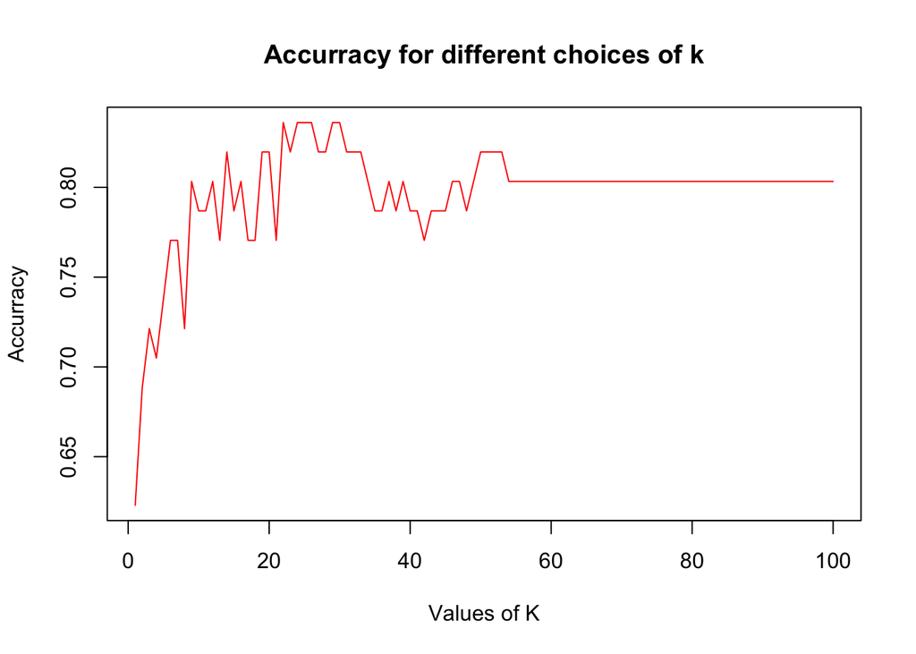

```r
plot(1:100,acc,type="l",col="red",xlab="Values of K",main="Accurracy for different choices of k",ylab="Accurracy")
```

```r
which.max(acc) # give the k that maximizes accuracy.
```

```
[1] 22
```

We fit the KNN model using an optimal k=22.

```r
X.train=train_data[ ,-1]
X.test=test_data[,-1]
Y.test=test_data$Cath
Y.train=train_data$Cath
knn_Predict=knn(X.train,X.test,Y.train,k=22)
predict.Y=knn_Predict
true.Y=Y.test
## Confusion Matrix
cm_knn=table(True = true.Y,Predicted=predict.Y)
cm_knn
```

```
    Predicted
True  0  1
   0  3  9
   1  2 47
```

```r
Accuacy2 = sum(diag(cm_knn))/sum(cm_knn)
cat("Accuracy for KNN:", Accuacy2, "\n")
```

```
Accuracy for KNN: 0.8196721
```

```r
TPR2 = (cm_knn[2,2])/(cm_knn[2,2]+cm_knn[2,1])
cat("TPR for KNN:", TPR2, "\n")
```

```
TPR for KNN: 0.9591837
```

## Naive Bayes

```r
nb.fit = naiveBayes(Cath~.,data=train_data)
nb.pred=predict(nb.fit,newdata=test_data)
cm_nb=table(True=true.response,Predicted=nb.pred)
cm_nb
```

```
    Predicted
True  0  1
   0  9  3
   1  4 45
```

```r
Accuacy3 = sum(diag(cm_nb))/sum(cm_nb)
cat("Accuracy for Naive Baye:", Accuacy3, "\n")
```

```
Accuracy for Naive Baye: 0.8852459
```

```r
TPR3 = (cm_nb[2,2])/(cm_nb[2,2]+cm_nb[2,1])
cat("TPR for Naive Baye:", TPR3, "\n")
```

```
TPR for Naive Baye: 0.9183673
```

## Support Vector machine

```r
svm_rad = svm(Cath ~ ., data = sani, kernel = "radial", cost = 5, gamma = 0.1, type="C-classification")

ypred_svmr =predict(svm_rad, test_data)
cm_svm1=table(True=true.response, predict = ypred_svmr)
cm_svm1
```

```
    predict
True  0  1
   0 11  1
   1  1 48
```

```r
Accuacy4 = sum(diag(cm_svm1))/sum(cm_svm1)
cat("Accuracy for SVM:", Accuacy4, "\n")
```

```
Accuracy for SVM: 0.9672131
```

```r
TPR4 = (cm_svm1[2,2])/(cm_svm1[2,2]+cm_svm1[2,1])
cat("TPR for SVM:", TPR4, "\n")
```

```
TPR for SVM: 0.9795918
```

Suppose we set cost and gamma at 30 and 0.1 respectively, we get the following results.

```r
svm_r2 = svm(Cath ~ ., data = sani, kernel = "radial", cost = 30, gamma = 0.1, type="C-classification")

ypred_svmr =predict(svm_r2, test_data)
cm_svm1=table(True=true.response, predict = ypred_svmr)

Accuacy4.1 = sum(diag(cm_svm1))/sum(cm_svm1)
cat("Accuracy for SVM:", Accuacy4.1, "\n")
```

```
Accuracy for SVM: 1
```

```r
TPR4.1 = (cm_svm1[2,2])/(cm_svm1[2,2]+cm_svm1[2,1])
cat("TPR for SVM:", TPR4.1, "\n")
```

```
TPR for SVM: 1
```

The rest of our analysis uses $cost=5$ and $gamma = 0.1$ for ROC analysis. This was the work we did in our project.

#### I propose we fit an SVM model that optimally selects tuning parameters.

Hereafter, we use an SVM specification that is robust to optimal tuning parameters.

```r
# Define the parameter grid
param_grid <- list(
  cost = 30^seq(-1, 2, by=.1),  # Example range: 0.1, 1, 10, 100
  gamma = 30^seq(-2, 1, by=.1)  # Example range: 0.01, 0.1, 1, 10
)
set.seed(18)
# Perform grid search with cross-validation
tune_result <- tune(
  svm,
  Cath ~ .,
  data = sani,
  kernel = "radial",
  ranges = param_grid,
  type = "C-classification"
)

# Print the best parameters
print(tune_result$best.parameters)
```

```
       cost       gamma
25 116.9418 0.001111111
```

#### Running the chunck code for optimal search repeatedly without setting seed yields different optimal results.This suggests the optimal is not unique to a given data.

We therefore use the SVM model with our initial choice of tuning parameters for the rest of our analysis.

#### Random forest (rf)

```r
set.seed(180752)
rf_model=randomForest(as.factor(Cath)~.,data=train_data,method="class",
                      mtry=3,     # Number of branch variables
                      ntree=1000) # Number of trees to grow

rf_predict=predict(rf_model,newdata=test_data,method="class")
cm_rf=table(True=true.response,Predicted=rf_predict)
cm_rf
```

```
    Predicted
True  0  1
   0  8  4
   1  3 46
```

```r
Accuacy5 = sum(diag(cm_rf))/sum(cm_rf)
cat("Accuracy for random forest:", Accuacy5, "\n")
```

```
Accuracy for random forest: 0.8852459
```

```r
TPR5 = (cm_rf[2,2])/(cm_rf[2,2]+cm_rf[2,1])
cat("TPR for random rorest:", TPR5, "\n")
```

```
TPR for random rorest: 0.9387755
```

#### Logistic Model

```r
pred=prediction(result_logistic,true.response)
perf_logistic=performance(pred,"tpr","fpr")
auc.log=performance(pred,"auc" )
auc3=auc.log@y.values
round(as.numeric(auc3),4)
```

```
[1] 0.8656
```

#### KNN Classifier

```r
## KNN
knn_Predict=knn(X.train,X.test,Y.train,k=22,prob = TRUE)
knn_Predict=attributes(knn_Predict)$prob
true.Y=Y.test
pred=prediction(knn_Predict,true.Y)
perf_knn=performance(pred,"tpr","fpr")
## Area under the curve
auc=performance(pred,"auc")
auc4=auc@y.values
round(as.numeric(auc4),4)
```

```
[1] 0.7406
```

#### Naive Bayes Classifier

```r
nb.response = naiveBayes(Cath~.,data=train_data)
nb.pred=predict(nb.response,newdata=test_data,type="raw")
nb.pred=nb.pred[,2]
predicted_nb =prediction(nb.pred, test_data$Cath)
perf_nb =performance(predicted_nb, "tpr", "fpr")
auc.nb=performance(predicted_nb,"auc" )
auc2=auc.nb@y.values
round(as.numeric(auc2),4)
```

```
[1] 0.8997
```

#### SVM Classifier

```r
response_svmr =attributes(predict(svm_rad, test_data, decision.values = TRUE))$decision.values
predicted_obj =prediction(response_svmr, test_data$Cath)
perf_svmr =performance(predicted_obj, "tpr", "fpr")
auc=performance(predicted_obj,"auc" )
auc1=auc@y.values
round(as.numeric(auc1),4)
```

```
[1] 0.9541
```

### Random Forest Classfier

```r
predictionr=predict(rf_model,newdata =test_data,type="prob" )
result=predictionr[,2]
true.response=test_data$Cath
pred=prediction(result,true.response)
perf_nb=performance(pred,"tpr","fpr")
auc=performance(pred,"auc")
auc_rf=auc@y.values
round(as.numeric(auc_rf),4)
```

```
[1] 0.8741
```

#### ROC Curve

For this plot, we include only one of our SVMs computed above.

[figure not shown]

```r
# Plot ROC curves for all three models
plot(perf_logistic, col = "blue", lwd=2, lty=6, main = "ROC Curves for the 5 Classifiers")
plot(perf_knn, col = "grey", lwd=1, lty=1, add = TRUE)
plot(perf_nb, col = "steelblue",lwd=2.5, lty=5, add = TRUE)
plot(perf_svmr, col = "red", lwd=1, lty=1, add = TRUE)
plot(perf_nb, col = "orange",lwd=3, lty=4, add = TRUE)

legend(0.65,0.5,
       legend=c("logistic:AUC=0.8656",
                "KNN:AUC=0.7406",
                "NB:AUC=0.8997",
                "SVM:AUC=0.9541",
                "RF:AUC=0.8741"),
       lwd=c(2,1,2.5,1,3),
       col=c("blue", "grey", "steelblue", "red", "orange"),
       lty=c(6,1,5,1,4),
       cex=0.7)
```

Comparing the coefficients of the classifiers, we see that the SVM performs better than the other classifiers using all the metrics we employed. It has the highest predictive accuracy rate, sensitivity, and AUC. The ROC curve above shows that SVM model has the highest AUC even without optimal choice of tuning parameters.

Our results suggest that the SVM model (a) can be manipulated to yield biased predictive accuracy and sensitivity (TPR) through the choice of tuning parameters. (b) may yield best predictive accuracy if tuning parameters are efficiently chose.